# R Notebook

```r
library(dplyr)
```

# Sustancias Legales

## E - tabaco

### el ultimo mes (días)

```r
nna <- C_e%>% filter(E_06 != 0)
sum(nna$E_06 == "99") # cuantas personas no contestaron
```

```
[1] 21
```

```r
nna <- nna %>% filter(E_06 != "99")
nrow(nna)
```

```
[1] 4748
```

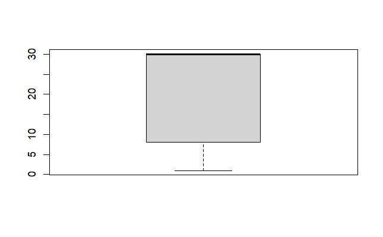

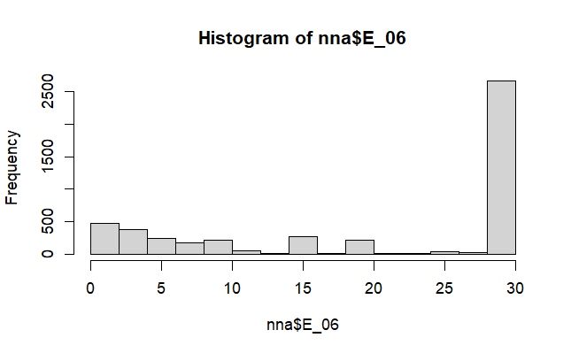

```r
boxplot(nna$E_06)
hist(nna$E_06)

quantile(nna$E_06, probs = 0.25)
```

```
25%
  8
```

Todo aquel que consuma mas de 8 días en el ultimo mes

### diarimente

```r
# Se borran los registros de "no aplica"
nna <- C_e %>% filter(E_09 != "0")
nrow(nna)
```

```
[1] 2884
```

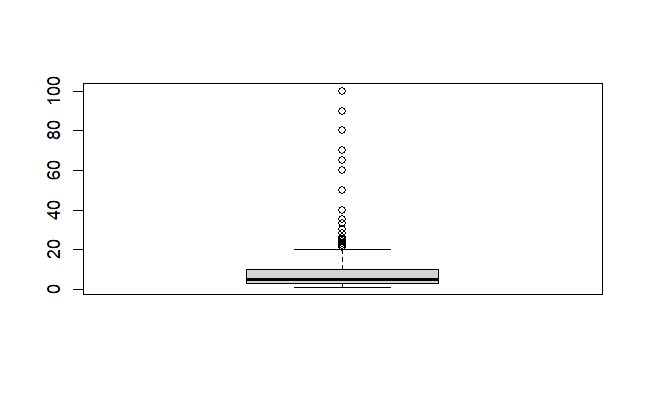

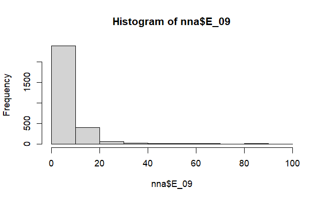

```r
boxplot(nna$E_09)
hist(nna$E_09)

quantile(nna$E_09, probs = 0.25)
```

```
25%
  3
```

### el ultimo mes (días)

```r
nna <- C_f%>% filter(F_08 != 0)
sum(nna$F_08 == "99") # cuantas personas no contestaron
```

```
[1] 35
```

```r
nna <- nna %>% filter(F_08 != "99")
nrow(nna)
```

```
[1] 14501
```

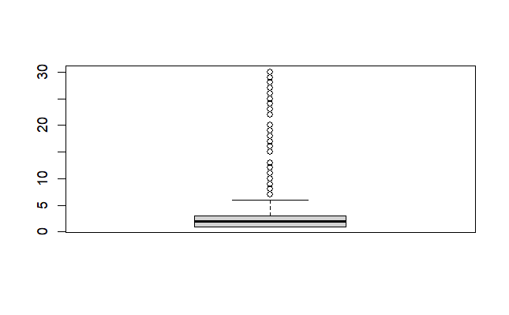

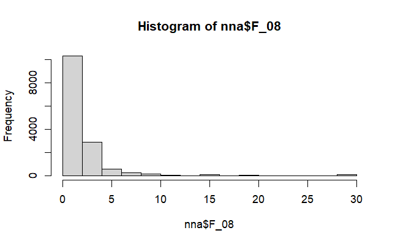

```r
boxplot(nna$F_08)
hist(nna$F_08)

quantile(nna$F_08, probs = 0.25)
```

```
25%
  1
```

```r
nna <- C_f%>% filter(F_09 != "na")
sum(nna$F_09 == "99") # cuantas personas no contestaron
```

```
[1] 0
```

```r
nna <- nna %>% filter(F_09 != "99") %>% mutate(F_09 = as.numeric(F_09))
nrow(nna)
```

```
[1] 14536
```

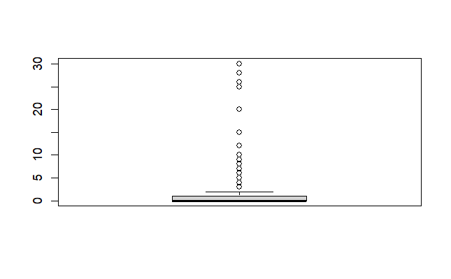

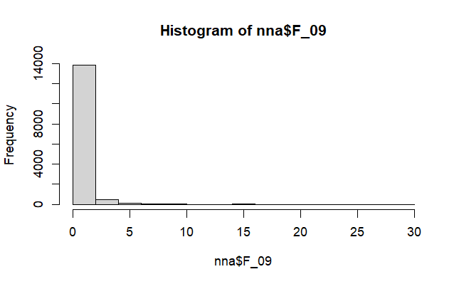

```r
boxplot(nna$F_09)
hist(nna$F_09)

quantile(nna$F_09, probs = 0.25)
```

```
25%
  0
```

### el ultimo año - Embriaguez

```r
nrow(nna)
```

```
[1] 26363
```

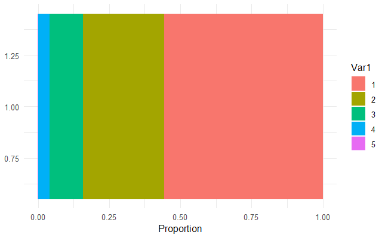

```r
ggplot(proportions, aes(x = 1, y = Freq, fill = Var1)) +
  geom_bar(stat = "identity") +
  coord_flip() +  # Rotate the plot to have bars side by side
  labs(x = NULL, y = "Proportion") +  # Remove x-axis label and set y-axis label
  theme_minimal()
quantile(as.integer(nna$F_14), 0.25)
```

```
25%
  1
```

Todos los que se hayan embriagado **al menos** de la “1”: nunca (“2”: al menos 1 vez al mes), se consideraría consumidor

## H - tranquilizantes

### el ultimo mes (días)

```r
nrow(nna)
```

```
[1] 127
```

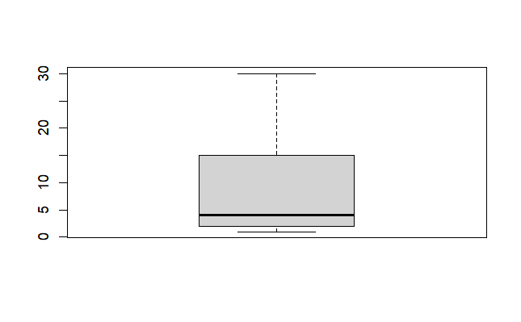

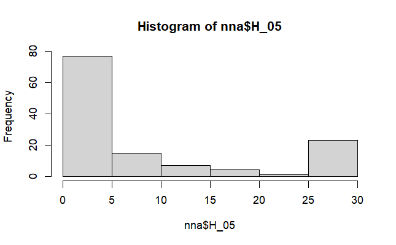

```r
boxplot(nna$H_05)
hist(nna$H_05)

quantile(nna$H_05, probs = 0.25)
```

```
25%
  2
```

Se definiría consumidor a aquel que haya consumido medicamentos tranquilizantes mas de dos días en el ultimo mes.

## I - estimulantes

### el ultimo mes (días)

```r
nrow(nna)
```

```
[1] 8
```

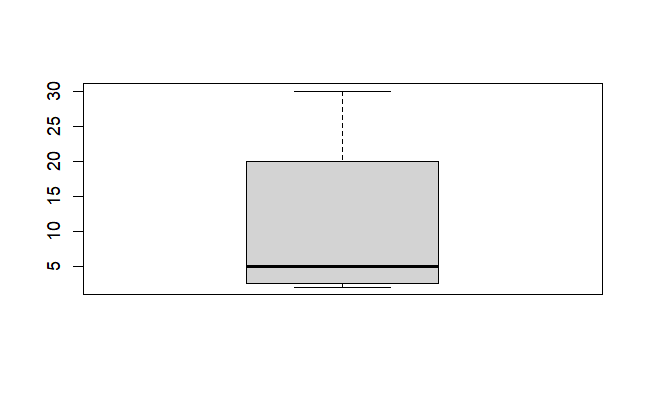

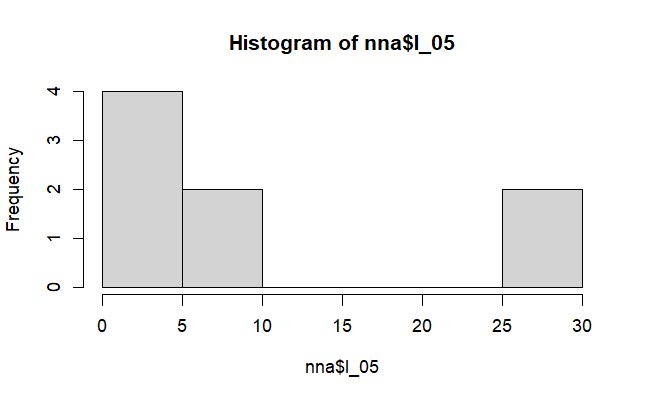

```r
boxplot(nna$I_05)
hist(nna$I_05)

quantile(nna$I_05, probs = 0.25)
```

```
 25%
2.75
```

Se definiría consumidor a aquel que haya consumido medicamentos estimulantes mas de 3 días en el ultimo mes.

## J - inhalables

### el ultimo año - (1)inhalables

```r
nrow(nna)
```

```
[1] 30
```

| Var1 | Freq |
| --- | --- |
| 1 | 0.13333333 |
| 2 | 0.53333333 |
| 3 | 0.10000000 |
| 4 | 0.20000000 |
| 5 | 0.03333333 |

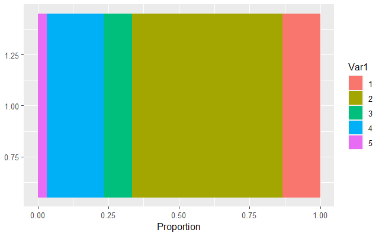

```r
proportions <- as.data.frame(prop.table(table(nna$J_03))); proportions


# Se mira el percentil 75% ya que el gráfico los pone al revés, iniciando por 5 (mas frecuentemente)
ggplot(proportions, aes(x = 1, y = Freq, fill = Var1)) +
  geom_bar(stat = "identity") +
  coord_flip() +
  labs(x = NULL, y = "Proportion")
```

```r
quantile(as.integer(nna$J_03), 0.25)
```

```
25%
  2
```

Todos los que hayan consumido pegantes/sacol, pinturas, thinner **al menos** de la “2”: Algunas veces durante los últimos 12 meses, se consideraría consumidor

### el ultimo año - (2) DICK, Ladys o fragancia

```r
nrow(nna)
```

```
[1] 14
```

| Var1 | Freq |
| --- | --- |
| 1 | 0.42857143 |
| 2 | 0.35714286 |
| 3 | 0.07142857 |
| 4 | 0.14285714 |

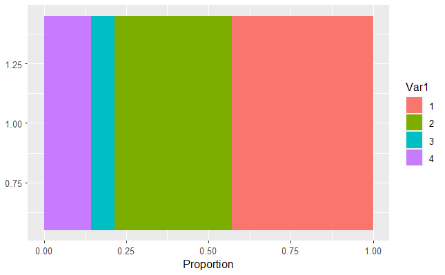

```r
proportions <- as.data.frame(prop.table(table(nna$J_09))); proportions


# Se mira el percentil 75% ya que el gráfico los pone al revés, iniciando por 5 (mas frecuentemente)
ggplot(proportions, aes(x = 1, y = Freq, fill = Var1)) +
  geom_bar(stat = "identity") +
  coord_flip() +
  labs(x = NULL, y = "Proportion")
```

```r
quantile(as.integer(nna$J_09), 0.25)
```

```
25%
  1
```

Todos los que hayan consumido DICK, Ladys o fragancia **al menos** de la “1”: Una sola vez, se consideraría consumidor

### (3) Popper

Para los que respondieron que habían consumido popper alguna vez en su vida solo se les pregunta si han consumido el ultimo año y si han consumido en los últimos 30 días, con posible respuestas: si, no y no contesta

## K - marihuana

### el ultimo año

```r
nrow(nna)
```

```
[1] 1210
```

| Var1 | Freq |
| --- | --- |
| 1 | 0.1198347 |
| 2 | 0.2495868 |
| 3 | 0.1710744 |
| 4 | 0.1785124 |
| 5 | 0.2809917 |

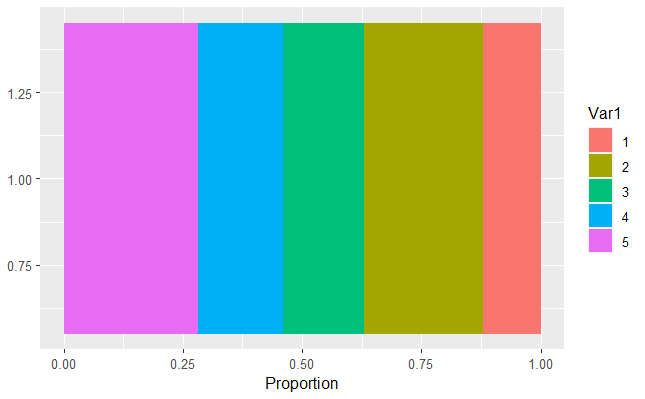

```r
proportions <- as.data.frame(prop.table(table(nna$K_04))); proportions


# Se mira el percentil 75% ya que el gráfico los pone al revés, iniciando por 5 (mas frecuentemente)
ggplot(proportions, aes(x = 1, y = Freq, fill = Var1)) +
  geom_bar(stat = "identity") +
  coord_flip() +
  labs(x = NULL, y = "Proportion")
```

```r
quantile(as.integer(nna$K_04), 0.25)
```

```
25%
  2
```

Todos los que hayan consumido **al menos** de la “2”: Algunas veces durante los últimos 12 meses, se consideraría consumidor

### el ultimo mes (días)

```r
nrow(nna)
```

```
[1] 818
```

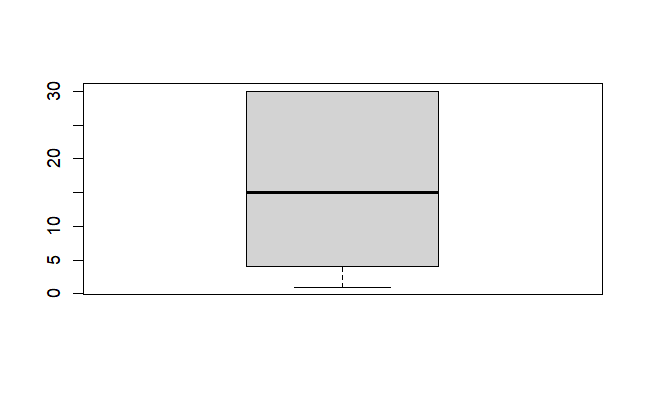

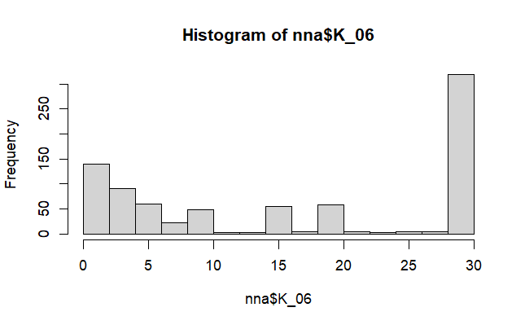

```r
boxplot(nna$K_06)
hist(nna$K_06)

quantile(nna$K_06, probs = 0.25)
```

```
25%
  4
```

## L - cocaína

## M - basuco

## N - extasis

## O - heroína

## P - otras